# Math 300 Lesson 16 Notes

### Simpson’s paradox

It is key in modeling to account for lurking variable. This [site](https://towardsdatascience.com/simpsons-paradox-and-interpreting-data-6a0443516765) Simpson’s paradox.

Here is a nice example from the `palmerpenguins` data package.

```r
library(palmerpenguins)
```

```r
penguin_df<-
  palmerpenguins::penguins %>%
  na.omit()
```

```r
head(penguin_df)
```

```
## # A tibble: 6 x 8
##   species island bill_length_mm bill_depth_mm flipper_length_~ body_mass_g sex
##   <fct>   <fct>           <dbl>         <dbl>            <int>       <int> <fct>
## 1 Adelie  Torge~           39.1          18.7              181        3750 male
## 2 Adelie  Torge~           39.5          17.4              186        3800 fema~
## 3 Adelie  Torge~           40.3          18                195        3250 fema~
## 4 Adelie  Torge~           36.7          19.3              193        3450 fema~
## 5 Adelie  Torge~           39.3          20.6              190        3650 male
## 6 Adelie  Torge~           38.9          17.8              181        3625 fema~
## # ... with 1 more variable: year <int>
```

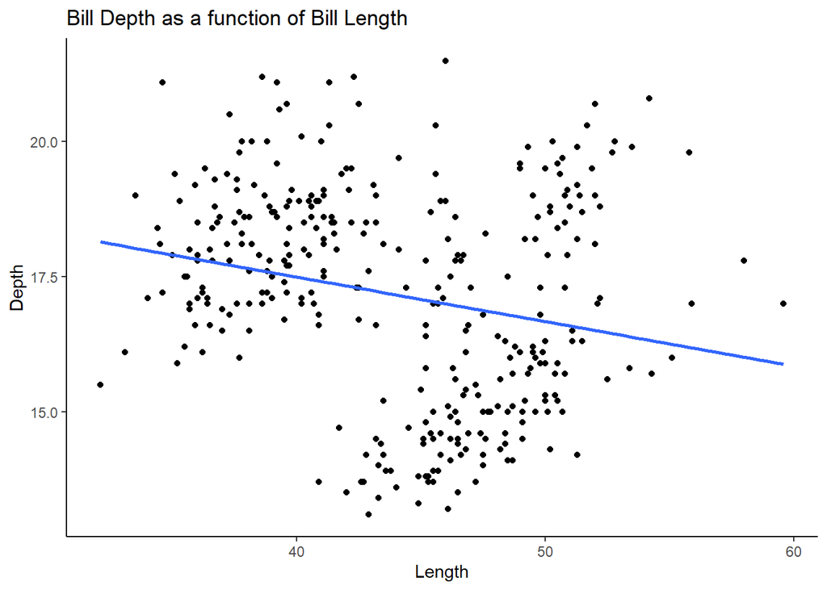

```r
penguin_df %>%
  ggplot(aes(x=bill_length_mm, y=bill_depth_mm)) +
  geom_point() +
  labs(x="Length", y="Depth", title="Bill Depth as a function of Bill Length") +
  theme_classic() +
  geom_smooth(method = "lm", se = FALSE)
```

From this we might as well conclude that the longer the bill, the less deep it is. However, if you drill down from the population level to the species level we see the opposite result.

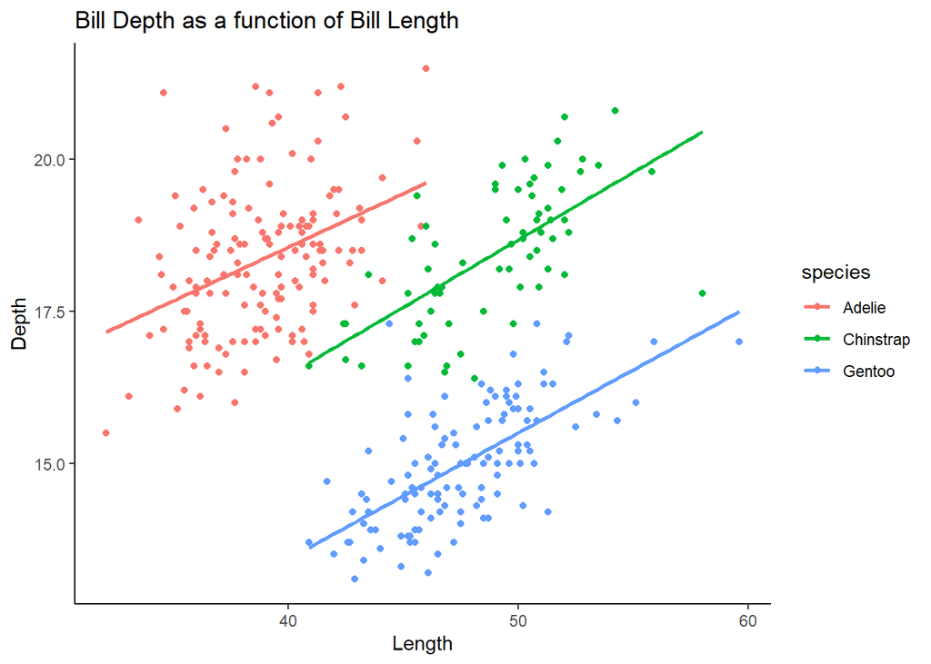

```r
penguin_df %>%
  ggplot(aes(x=bill_length_mm, y=bill_depth_mm,
             color=species)) +
  geom_point() +
  labs(x="Length", y="Depth", title="Bill Depth as a function of Bill Length") +
  theme_classic() +
  geom_smooth(method = "lm", se = FALSE)
```

Explain these results in terms of a confounding variable.

## Documenting software

- File creation date: 2022-06-27
- R version 4.1.3 (2022-03-10)
- `tidyverse` package version: 1.3.1
- `skimr` package version: 2.1.4
- `palmerpenguins` package version: 0.1.0
- `moderndive` package version: 0.5.4